# Assignment 2 (Solution)

## Programming for Data Science (BUAN 6340)

### Due Date: Oct 20, 2019 11:59pm

Deliverables:

- Write down your codes in the given cells described in this file, denoted as "YOUR CODES"
- Use "download as" in the "file" menu to convert your ipython file to a .html file
- Submit both .ipynb and .html files to the eLearning (you might need to compress them into one single file)

This assignment covers data manipulation and visualization

The total score: 100

```python
NAME = "Vikrant Nakod"
Session = "BUAN6340.501 Fri 7:00pm-9:45pm"
```

In this assignment, we will explore an economic indicator [dataset](https://www.kaggle.com/worldbank/world-development-indicators).

Please downloand **indicator.csv** from eLearning.

```python
import numpy as np
import pandas as pd
import matplotlib.pyplot as plt
```

```python
#Import data
world = pd.read_csv('Indicators.csv')
world.shape
```

```
(5656458, 6)
```

```python
world.head()
```

|  | CountryName | CountryCode | IndicatorName | IndicatorCode | Year | Value |
| --- | --- | --- | --- | --- | --- | --- |
| 0 | Arab World | ARB | Adolescent fertility rate (births per 1,000 wo... | SP.ADO.TFRT | 1960 | 1.335609e+02 |
| 1 | Arab World | ARB | Age dependency ratio (% of working-age populat... | SP.POP.DPND | 1960 | 8.779760e+01 |
| 2 | Arab World | ARB | Age dependency ratio, old (% of working-age po... | SP.POP.DPND.OL | 1960 | 6.634579e+00 |
| 3 | Arab World | ARB | Age dependency ratio, young (% of working-age ... | SP.POP.DPND.YG | 1960 | 8.102333e+01 |
| 4 | Arab World | ARB | Arms exports (SIPRI trend indicator values) | MS.MIL.XPRT.KD | 1960 | 3.000000e+06 |

## Part I: Initial Exploration (18 points)

**Use one or two lines to answer each of the following FIVE questions**

Hint: https://pandas.pydata.org/pandas-docs/stable/reference/api/pandas.unique.html

**Q1.1** How many UNIQUE country names are there? (3 points)

```python
# YOUR CODES


print("Unique country count = {} ".format(len(world['CountryName'].unique().tolist())))
```

```
Unique country count = 247
```

**Q1.2** How many years of data do we have? (3 points)

```python
# YOUR CODES

years_data = world['Year'].unique().tolist()
len(years_data)
```

```
56
```

**Q1.3** What's the range of years? (3 points)

```python
# YOUR CODES


print("Year range = {} to {}".format(min_year,max_year))
```

[output not shown]

**Q1.4** How many unique indicators? (3 points)

```python
# YOUR CODES


print("Unique indicators count = {} ".format(len(world['IndicatorName'].unique().tolist())))
```

```
Unique indicators count = 1344
```

**Q1.5** How many unique indiactors does United States have in 2000? (6 points)

```python
# YOUR CODES

USAin2000 = world[(world['CountryName'] == 'United States') & (world['Year']== 2000)]
print("Unique Indicators count for USA = {} ".format(len(USAin2000['IndicatorName'].unique())))
```

```
Unique Indicators count for USA = 646
```

## Part II: Visualizaion (60 points)

### Let's pick a country and an indicator to explore: CO2 Emissions per capita and the USA

**Q2.1** Create a new dataframe where country = United State & Indicator = 'CO2 emissions (metric tons per capita)' (10 points)

Expected output: size of the dataframe and the first 5 lines of the dataframe

```python
# YOUR CODES


new_df1 = world[(world['CountryName'] == 'United States') & (world['IndicatorName'] == 'CO2 emissions (metric tons per capita)')]
new_df1.head()
```

|  | CountryName | CountryCode | IndicatorName | IndicatorCode | Year | Value |
| --- | --- | --- | --- | --- | --- | --- |
| 22232 | United States | USA | CO2 emissions (metric tons per capita) | EN.ATM.CO2E.PC | 1960 | 15.999779 |
| 48708 | United States | USA | CO2 emissions (metric tons per capita) | EN.ATM.CO2E.PC | 1961 | 15.681256 |
| 77087 | United States | USA | CO2 emissions (metric tons per capita) | EN.ATM.CO2E.PC | 1962 | 16.013937 |
| 105704 | United States | USA | CO2 emissions (metric tons per capita) | EN.ATM.CO2E.PC | 1963 | 16.482762 |
| 134742 | United States | USA | CO2 emissions (metric tons per capita) | EN.ATM.CO2E.PC | 1964 | 16.968119 |

**Q2.2** Plot the trend of CO2 emissions over time in USA (10 points)

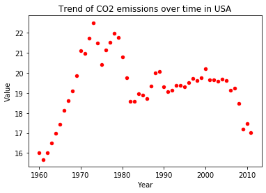

```python
%matplotlib inline

# YOUR CODES


new_df1.plot(kind='scatter',x='Year',y='Value',color='red')
plt.title('Trend of CO2 emissions over time in USA')
plt.show()
```

### But how do the USA's numbers relate to those of other countries?

**Q2.3** (20 points)

- select CO2 emissions per capital for all countries in 2011
- plot a histogram of the emmissions per capita by country
- indicate the position of USA in the plot

```python
# YOUR CODES

#select CO2 emissions per capital for all countries in 2011

req_indicator = 'CO2 emissions \(metric'
req_year = 2011

IndName = world['IndicatorName'].str.contains(req_indicator)
Reqyear = world['Year'].isin([req_year])

# apply our mask
Metric_2011 = world[IndName & Reqyear]
Metric_2011.head()
```

|  | CountryName | CountryCode | IndicatorName | IndicatorCode | Year | Value |
| --- | --- | --- | --- | --- | --- | --- |
| 5026275 | Arab World | ARB | CO2 emissions (metric tons per capita) | EN.ATM.CO2E.PC | 2011 | 4.724500 |
| 5026788 | Caribbean small states | CSS | CO2 emissions (metric tons per capita) | EN.ATM.CO2E.PC | 2011 | 9.692960 |
| 5027295 | Central Europe and the Baltics | CEB | CO2 emissions (metric tons per capita) | EN.ATM.CO2E.PC | 2011 | 6.911131 |
| 5027870 | East Asia & Pacific (all income levels) | EAS | CO2 emissions (metric tons per capita) | EN.ATM.CO2E.PC | 2011 | 5.859548 |
| 5028456 | East Asia & Pacific (developing only) | EAP | CO2 emissions (metric tons per capita) | EN.ATM.CO2E.PC | 2011 | 5.302499 |

```
C:\Users\Home Laptop\Anaconda3\lib\site-packages\ipykernel_launcher.py:13: MatplotlibDeprecationWarning:
The 'normed' kwarg was deprecated in Matplotlib 2.1 and will be removed in 3.1. Use 'density' instead.
  del sys.path[0]
```

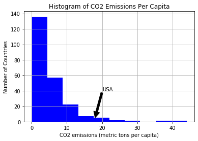

```python
#plot a histogram of the emmissions per capita by country
#indicate the position of USA in the plot

fig, ax = plt.subplots()

ax.annotate("USA",
            xy=(18, 5),
            xytext=(20, 40),
            arrowprops=dict(facecolor='black')
            )


plt.hist(Metric_2011['Value'], 10, normed=False, facecolor='blue')

plt.xlabel(new_df1['IndicatorName'].iloc[0])
plt.ylabel('Number of Countries')
plt.title('Histogram of CO2 Emissions Per Capita')

#plt.axis([10, 22, 0, 14])
plt.grid(True)

plt.show()
```

### ScatterPlot for comparing GDP against CO2 emissions (per capita) in USA

**Q2.4** (20 points)

- Select GDP Per capital for USA (Indicator = 'GDP per capita (constant 2005 US$)')
- Use a scattor plot to explore the relationship between GDP and CO2 emissions

Hint: before plotting, you have to make sure that the two measures cover the same period of time

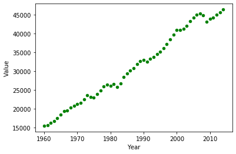

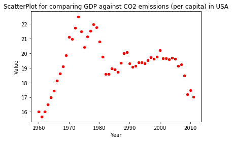

```python
# YOUR CODES


new_df2 = world[(world['CountryName'] == 'United States') & (world['IndicatorName'] == 'GDP per capita (constant 2005 US$)')]
new_df2.head()
new_df2.plot(kind='scatter',x='Year',y='Value',color='green')
new_df1.plot(kind='scatter',x='Year',y='Value',color='red')
plt.title('ScatterPlot for comparing GDP against CO2 emissions (per capita) in USA')
plt.show()
```

## Part III: We are missing data (22 points)

The above analyses have suggested that not all countries have all indicators for all years. Thus, let's pick indicators and countries which have data over the same time range

```python
# range of the three variables

countries_list = world['CountryName'].unique().tolist()
indicators_list = world['IndicatorName'].unique().tolist()

yearfilter = range(2000,2012)
```

**Q3.1** write a program to find **TWO** countries from **countries_list** and **ONE** indicator from **indicators_list** so that the selected two countries have records of the indicator from 2000 to 2011 (the time range is defined in **yearfilter**). (16 points)

For example, both Bermuda and Costa Rica have records of the indicator "Merchandise exports to developing economies outside region (% of total merchandise exports)" from 2000 to 2011.

Hint: https://pandas.pydata.org/pandas-docs/stable/reference/api/pandas.DataFrame.isin.html

Expected output:

- Two dataframe, indicating the two countries separately
- The two dataframe only include data with the specific indicator
- Both dataframe cover the same period of time from 2000 to 2011

```python
import random
random.seed(25) # generate the same random number every time

# YOUR CODES

import random
countries_list = world['CountryName'].unique().tolist()
indicators_list = world['IndicatorName'].unique().tolist()

yearfilter = range(2000,2012)
while True:
    countries_selected= random.sample(countries_list, 2)
    indicator_selected = random.sample(indicators_list, 1)
    df = world[(world['IndicatorName'] == indicator_selected[0]) & (world['Year']>=2000) & (world['Year']<=2012)]
    df1=df[(world['CountryName'] == countries_selected[0])]
    df2=df[(world['CountryName'] == countries_selected[1])]
    if df1.shape[0] == df2.shape[0] == 13:
        print(df1,df2)
        break


'''
Hints:

Step 1: pick one indicator from the indicator_list (you can use loops or randomly draw from indicators_list)
Step 2: given the selected indicator, pick two countries that have records over the 12 years (2000-2011).

You can use loops (for or while) to repeat the above two steps until you find the satisfying countries and indicators.
'''
```

```
C:\Users\Home Laptop\Anaconda3\lib\site-packages\ipykernel_launcher.py:15: UserWarning: Boolean Series key will be reindexed to match DataFrame index.
  from ipykernel import kernelapp as app
C:\Users\Home Laptop\Anaconda3\lib\site-packages\ipykernel_launcher.py:16: UserWarning: Boolean Series key will be reindexed to match DataFrame index.
  app.launch_new_instance()
```

```
        CountryName CountryCode  \
3246521   Indonesia         IDN
3398820   Indonesia         IDN
3551438   Indonesia         IDN
3705674   Indonesia         IDN
3861067   Indonesia         IDN
4030691   Indonesia         IDN
4209180   Indonesia         IDN
4388007   Indonesia         IDN
4568333   Indonesia         IDN
4747484   Indonesia         IDN
4930359   Indonesia         IDN
5112067   Indonesia         IDN
5287729   Indonesia         IDN

```

[output cut: 72 more lines]

[output not shown]

**Q3.2** Plot the correlation of the two countries with the selected indicator (scatter plots) (6 points)

```python
# YOUR CODES

df1
```

|  | CountryName | CountryCode | IndicatorName | IndicatorCode | Year | Value |
| --- | --- | --- | --- | --- | --- | --- |
| 3246521 | Indonesia | IDN | Discrepancy in expenditure estimate of GDP (cu... | NY.GDP.DISC.CN | 2000 | -1.314450e+13 |
| 3398820 | Indonesia | IDN | Discrepancy in expenditure estimate of GDP (cu... | NY.GDP.DISC.CN | 2001 | -1.398630e+13 |
| 3551438 | Indonesia | IDN | Discrepancy in expenditure estimate of GDP (cu... | NY.GDP.DISC.CN | 2002 | -4.699500e+13 |
| 3705674 | Indonesia | IDN | Discrepancy in expenditure estimate of GDP (cu... | NY.GDP.DISC.CN | 2003 | -1.853552e+14 |
| 3861067 | Indonesia | IDN | Discrepancy in expenditure estimate of GDP (cu... | NY.GDP.DISC.CN | 2004 | -8.767326e+13 |
| 4030691 | Indonesia | IDN | Discrepancy in expenditure estimate of GDP (cu... | NY.GDP.DISC.CN | 2005 | -4.716298e+13 |
| 4209180 | Indonesia | IDN | Discrepancy in expenditure estimate of GDP (cu... | NY.GDP.DISC.CN | 2006 | -7.041569e+13 |
| 4388007 | Indonesia | IDN | Discrepancy in expenditure estimate of GDP (cu... | NY.GDP.DISC.CN | 2007 | -3.364699e+13 |
| 4568333 | Indonesia | IDN | Discrepancy in expenditure estimate of GDP (cu... | NY.GDP.DISC.CN | 2008 | 1.031085e+14 |
| 4747484 | Indonesia | IDN | Discrepancy in expenditure estimate of GDP (cu... | NY.GDP.DISC.CN | 2009 | -1.167909e+14 |
| 4930359 | Indonesia | IDN | Discrepancy in expenditure estimate of GDP (cu... | NY.GDP.DISC.CN | 2010 | -1.654963e+07 |
| 5112067 | Indonesia | IDN | Discrepancy in expenditure estimate of GDP (cu... | NY.GDP.DISC.CN | 2011 | 4.616021e+12 |
| 5287729 | Indonesia | IDN | Discrepancy in expenditure estimate of GDP (cu... | NY.GDP.DISC.CN | 2012 | -2.718149e+13 |

```python
df2
```

|  | CountryName | CountryCode | IndicatorName | IndicatorCode | Year | Value |
| --- | --- | --- | --- | --- | --- | --- |
| 3255332 | Korea, Rep. | KOR | Discrepancy in expenditure estimate of GDP (cu... | NY.GDP.DISC.CN | 2000 | -6.691000e+11 |
| 3407228 | Korea, Rep. | KOR | Discrepancy in expenditure estimate of GDP (cu... | NY.GDP.DISC.CN | 2001 | -3.783000e+11 |
| 3560220 | Korea, Rep. | KOR | Discrepancy in expenditure estimate of GDP (cu... | NY.GDP.DISC.CN | 2002 | -8.470000e+11 |
| 3714419 | Korea, Rep. | KOR | Discrepancy in expenditure estimate of GDP (cu... | NY.GDP.DISC.CN | 2003 | -9.760000e+11 |
| 3870125 | Korea, Rep. | KOR | Discrepancy in expenditure estimate of GDP (cu... | NY.GDP.DISC.CN | 2004 | -8.857000e+11 |
| 4040832 | Korea, Rep. | KOR | Discrepancy in expenditure estimate of GDP (cu... | NY.GDP.DISC.CN | 2005 | -7.804000e+11 |
| 4219055 | Korea, Rep. | KOR | Discrepancy in expenditure estimate of GDP (cu... | NY.GDP.DISC.CN | 2006 | -8.064000e+11 |
| 4398103 | Korea, Rep. | KOR | Discrepancy in expenditure estimate of GDP (cu... | NY.GDP.DISC.CN | 2007 | -1.215000e+11 |
| 4578346 | Korea, Rep. | KOR | Discrepancy in expenditure estimate of GDP (cu... | NY.GDP.DISC.CN | 2008 | -8.807000e+11 |
| 4757251 | Korea, Rep. | KOR | Discrepancy in expenditure estimate of GDP (cu... | NY.GDP.DISC.CN | 2009 | 2.988000e+11 |
| 4940647 | Korea, Rep. | KOR | Discrepancy in expenditure estimate of GDP (cu... | NY.GDP.DISC.CN | 2010 | 2.000000e+08 |
| 5121661 | Korea, Rep. | KOR | Discrepancy in expenditure estimate of GDP (cu... | NY.GDP.DISC.CN | 2011 | 2.400000e-01 |
| 5297288 | Korea, Rep. | KOR | Discrepancy in expenditure estimate of GDP (cu... | NY.GDP.DISC.CN | 2012 | -2.000000e+08 |

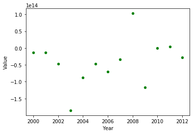

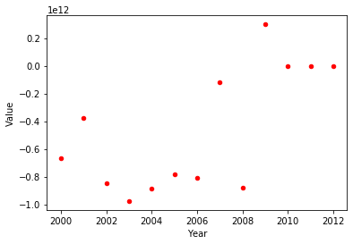

```python
df1.plot(kind='scatter',x='Year',y='Value',color='green')
df2.plot(kind='scatter',x='Year',y='Value',color='red')
```